# Analysis of a dataset containing information about wines from northern Portugal

## 1. Analysis of wines

The dataset we’ll be working with comes from [kaggle.com](https://www.kaggle.com/datasets/shelvigarg/wine-quality-dataset/data) and includes info on both red and white “Vinho Verde” wines — a variety from northern Portugal.

In this project, we’re going to explore how well *linear regression* can model the data.

*Linear regression* is basically a way to figure out how one variable (like wine quality) is influenced by others (like acidity, alcohol content, etc.). We try to draw a line through the data points that best captures the trend or relationship between them.

But before we dive into any analysis, let’s load up the necessary libraries so that everything runs smoothly.

```r
library(car)
library(corrplot)
library(dplyr)
library(faraway)
library(lmtest)
library(MASS)
library(nortest)
library(RColorBrewer)
```

## 2. The Data – Structure and Classification

Let’s load the winequalityN.csv file and take a quick look at the structure of the dataset.

```r
wine <- read.csv("C:\\Users\\Nikola\\Documents\\Nikola Chmielewska\\R\\Datasets\\winequalityN.csv")
str(wine)
```

```
## 'data.frame':    6497 obs. of  13 variables:
##  $ type                : chr  "white" "white" "white" "white" ...
##  $ fixed.acidity       : num  7 6.3 8.1 7.2 7.2 8.1 6.2 7 6.3 8.1 ...
##  $ volatile.acidity    : num  0.27 0.3 0.28 0.23 0.23 0.28 0.32 0.27 0.3 0.22 ...
##  $ citric.acid         : num  0.36 0.34 0.4 0.32 0.32 0.4 0.16 0.36 0.34 0.43 ...
##  $ residual.sugar      : num  20.7 1.6 6.9 8.5 8.5 6.9 7 20.7 1.6 1.5 ...
##  $ chlorides           : num  0.045 0.049 0.05 0.058 0.058 0.05 0.045 0.045 0.049 0.044 ...
##  $ free.sulfur.dioxide : num  45 14 30 47 47 30 30 45 14 28 ...
##  $ total.sulfur.dioxide: num  170 132 97 186 186 97 136 170 132 129 ...
##  $ density             : num  1.001 0.994 0.995 0.996 0.996 ...
##  $ pH                  : num  3 3.3 3.26 3.19 3.19 3.26 3.18 3 3.3 3.22 ...
##  $ sulphates           : num  0.45 0.49 0.44 0.4 0.4 0.44 0.47 0.45 0.49 0.45 ...
##  $ alcohol             : num  8.8 9.5 10.1 9.9 9.9 10.1 9.6 8.8 9.5 11 ...
##  $ quality             : int  6 6 6 6 6 6 6 6 6 6 ...
```

```r
unique(wine$type)
```

```
## [1] "white" "red"
```

From the command above, we can see that the dataset includes information on two wine types: red and white.

Now, let’s break down the variables included in the dataset to better understand what we’re working with:

| Name | Description |
| --- | --- |
| type | Type of wine (white or red) |
| fixed.acidity | Fixed acidity |
| volatile acidity | Volatile acidity |
| citric acid | Citric acid |
| residual sugar | Residual sugar |
| chlorides | Chlorides |
| free sulfur dioxide | Free sulfur dioxide |
| total sulfur dioxide | Total sulfur dioxide |
| density | Density |
| pH – potential of hydrogen | Acidity/basicity (pH level) |
| sulphates | Sulphates |
| alcohol | Alcohol content |
| quality | Wine quality rating |

To get a better feel for the data, let’s look at a summary:

```r
summary(wine)
```

```
##      type           fixed.acidity    volatile.acidity  citric.acid
##  Length:6497        Min.   : 3.800   Min.   :0.0800   Min.   :0.0000
##  Class :character   1st Qu.: 6.400   1st Qu.:0.2300   1st Qu.:0.2500
##  Mode  :character   Median : 7.000   Median :0.2900   Median :0.3100
##                     Mean   : 7.217   Mean   :0.3397   Mean   :0.3187
##                     3rd Qu.: 7.700   3rd Qu.:0.4000   3rd Qu.:0.3900
##                     Max.   :15.900   Max.   :1.5800   Max.   :1.6600
##                     NA's   :10       NA's   :8        NA's   :3
##  residual.sugar     chlorides       free.sulfur.dioxide total.sulfur.dioxide
##  Min.   : 0.600   Min.   :0.00900   Min.   :  1.00      Min.   :  6.0
##  1st Qu.: 1.800   1st Qu.:0.03800   1st Qu.: 17.00      1st Qu.: 77.0
##  Median : 3.000   Median :0.04700   Median : 29.00      Median :118.0
##  Mean   : 5.444   Mean   :0.05604   Mean   : 30.53      Mean   :115.7
##  3rd Qu.: 8.100   3rd Qu.:0.06500   3rd Qu.: 41.00      3rd Qu.:156.0
##  Max.   :65.800   Max.   :0.61100   Max.   :289.00      Max.   :440.0
##  NA's   :2        NA's   :2
##     density             pH          sulphates         alcohol
##  Min.   :0.9871   Min.   :2.720   Min.   :0.2200   Min.   : 8.00
##  1st Qu.:0.9923   1st Qu.:3.110   1st Qu.:0.4300   1st Qu.: 9.50
##  Median :0.9949   Median :3.210   Median :0.5100   Median :10.30
##  Mean   :0.9947   Mean   :3.218   Mean   :0.5312   Mean   :10.49
##  3rd Qu.:0.9970   3rd Qu.:3.320   3rd Qu.:0.6000   3rd Qu.:11.30
##  Max.   :1.0390   Max.   :4.010   Max.   :2.0000   Max.   :14.90
##                   NA's   :9       NA's   :4
##     quality
##  Min.   :3.000
##  1st Qu.:5.000
##  Median :6.000
##  Mean   :5.818
##  3rd Qu.:6.000
##  Max.   :9.000
##
```

Before diving in deeper, let’s also check whether there are any missing values in the dataset.

```r
(sapply(wine, function(x) {sum(is.na(x))}))
```

```
##                 type        fixed.acidity     volatile.acidity
##                    0                   10                    8
##          citric.acid       residual.sugar            chlorides
##                    3                    2                    2
##  free.sulfur.dioxide total.sulfur.dioxide              density
##                    0                    0                    0
##                   pH            sulphates              alcohol
##                    9                    4                    0
##              quality
##                    0
```

As we can see, there are some NA values in the table. Since they represent only a small portion of the data, we’ll go ahead and drop those rows. Missing data could affect the quality of our analysis later on, so it’s better to clean it up now.

```r
wine_clean <- na.omit(wine) #deleting rows containing NA values
```

Once we remove the rows with missing values, let’s take another look at our updated dataset.

```r
(sapply(wine_clean, function(x) {sum(is.na(x))}))
```

```
##                 type        fixed.acidity     volatile.acidity
##                    0                    0                    0
##          citric.acid       residual.sugar            chlorides
##                    0                    0                    0
##  free.sulfur.dioxide total.sulfur.dioxide              density
##                    0                    0                    0
##                   pH            sulphates              alcohol
##                    0                    0                    0
##              quality
##                    0
```

Now everything looks good — no missing data, so our dataset is ready to go!

In this dataset, the variable we’re trying to predict is quality, which represents the wine’s rating. All the other variables are independent (predictor) variables, and they’re numerical in nature. As for quality, it can actually be seen in two ways: either as a continuous numeric variable or as an ordinal categorical variable (since it reflects a quality rating).

In our analysis, we’ll first treat quality as a numeric variable when applying linear regression. But later on, when we build a proportional odds model, we’ll treat it as an ordinal categorical variable. Also, for hypothesis testing, we’ll be using a significance level of *α = 0.05*.

### 2.1. Splitting the Dataset

We’re going to start by splitting the dataset based on the wine type — white and red. For this analysis, we’ll keep things simple and focus only on white wine. If you want, you can run a similar analysis later for red wine by following the same steps.

```r
white_wine <- subset(wine_clean, type == "white")
```

Next, we’ll drop any text-based columns since we’re only interested in working with numerical data for this part of the project.

```r
white_numeric <- white_wine[sapply(white_wine, is.numeric)]
```

Now let’s create a few helper variables that’ll make it easier to divide the dataset into three separate subsets.

```r
N <- nrow(white_numeric)
I <- (1:N)
```

Time to randomly generate the indexes for the split.

```r
set.seed(300)
I_l <- sample.int(N, size = round(N/2)) #50% of the data
I_v <- sample(setdiff(I, I_l), size = round(N/4)) #25% of the data
I_t <- setdiff(setdiff(I, I_l), I_v) #25% of the data
```

We’ll use those indexes to create three data subsets: a training set, a validation set, and a test set — with 50%, 25%, and 25% of the data, respectively.

```r
lrn <- white_numeric[I_l,] #training set
val <- white_numeric[I_v,] #validation set
tst <- white_numeric[I_t,] #test set
```

And just like that, we’ve split our data into three parts — all set for the next steps in the analysis.

### 2.2 Variable Correlation

Before jumping into building a linear regression model, let’s first take a look at the correlation heatmap for the variables in our training set.

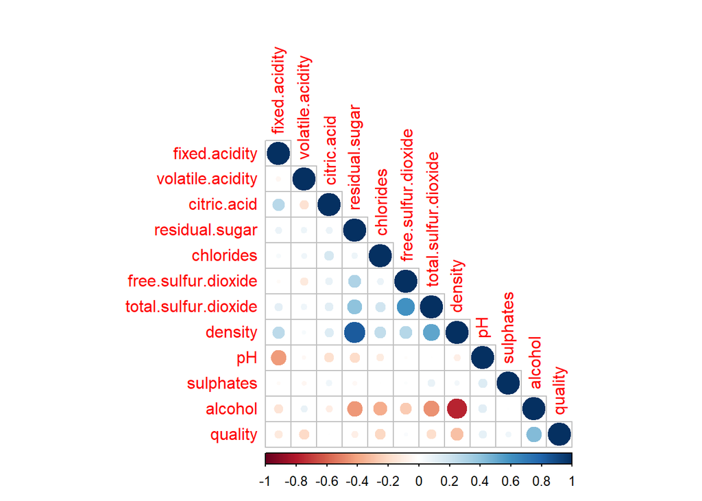

```r
white_matrix <- cor(lrn)
corrplot(white_matrix, type = "lower")
```

*Correlation* tells us how two variables move together. The Pearson correlation coefficient (which ranges from -1 to 1) is a handy number that shows us the strength and direction of the relationship.

A positive value means both variables tend to increase together, while a negative value means that as one goes up, the other tends to go down. The closer the value is to either -1 or 1, the stronger the relationship. If it’s closer to 0, it usually means there’s not much of a connection.

From the plot, we can see that ‘alcohol’ and ‘density’ show the strongest relationships with wine ‘quality’ — alcohol is positively correlated, and density is negatively correlated.

It’s also worth noting that ‘density’ is strongly tied to ‘residual sugar’, and there’s also a clear link between ‘alcohol’ and ‘density’. Based on that, we’ll try building models that exclude either ‘residual sugar’ or ‘alcohol’ (or both) to see how things change.

We’ll also try out *Principal Component Analysis (PCA)* to compare this approach with standard regression.

*PCA* is a technique that transforms the original variables into a new set of uncorrelated variables (called principal components), which can make our models cleaner and sometimes more effective.

## 3. Linear Regression Models

### 3.1. Basic Models

We’re going to build several linear regression models where we try to predict wine ‘quality’ using different sets of features:

- Full model: uses all variables from the training set.
- No sugar: drops the ‘residual sugar’ variable.
- No alcohol: drops the ‘alcohol’ variable.
- No sugar & no alcohol: drops both ‘residual sugar’ and ‘alcohol’.

To make our lives easier, we’ll create a function that builds each of these models for us.

```r
models <<- list()
countM  = 0
add_model = function(name, model, ispca){
  models <<- append(models, list(name, model, ispca))
  countM <<- countM + 1
}
get_name  = function(index){models[[index*3-3+1]]}
get_model = function(index){models[[index*3-3+2]]}
is_pca    = function(index){models[[index*3-3+3]]}

add_model('full',                 lm(quality ~ .,                            data = lrn), FALSE)
add_model('no sugar',             lm(quality ~ . - residual.sugar,           data = lrn), FALSE)
add_model('no alcohol',           lm(quality ~ .                  - alcohol, data = lrn), FALSE)
add_model('no sugar, no alcohol', lm(quality ~ . - residual.sugar - alcohol, data = lrn), FALSE)
```

Then we’ll display a summary for each model, in the order listed above.

```r
for(i in 1:countM){
  print(get_name(i))
  print(summary(get_model(i)))
}
```

```
## [1] "full"
##
## Call:
## lm(formula = quality ~ ., data = lrn)
##
## Residuals:
##     Min      1Q  Median      3Q     Max
## -3.4424 -0.4903 -0.0343  0.4565  2.4520
##
## Coefficients:
##                        Estimate Std. Error t value Pr(>|t|)
## (Intercept)           1.101e+02  2.304e+01   4.779 1.87e-06 ***
## fixed.acidity         3.955e-02  2.752e-02   1.437    0.151
## volatile.acidity     -1.904e+00  1.576e-01 -12.085  < 2e-16 ***
## citric.acid           1.402e-01  1.302e-01   1.076    0.282
## residual.sugar        7.067e-02  9.747e-03   7.251 5.56e-13 ***
## chlorides             1.601e-01  7.646e-01   0.209    0.834
## free.sulfur.dioxide   4.733e-03  1.205e-03   3.928 8.79e-05 ***
## total.sulfur.dioxide -7.247e-04  5.193e-04  -1.396    0.163
## density              -1.101e+02  2.339e+01  -4.707 2.65e-06 ***
## pH                    6.457e-01  1.424e-01   4.536 6.01e-06 ***
## sulphates             5.512e-01  1.378e-01   3.999 6.55e-05 ***
## alcohol               2.446e-01  3.013e-02   8.117 7.50e-16 ***
## ---
## Signif. codes:  0 '***' 0.001 '**' 0.01 '*' 0.05 '.' 0.1 ' ' 1
##
## Residual standard error: 0.7422 on 2423 degrees of freedom
## Multiple R-squared:  0.2916, Adjusted R-squared:  0.2884
## F-statistic: 90.68 on 11 and 2423 DF,  p-value: < 2.2e-16
##
## [1] "no sugar"
##
## Call:
## lm(formula = quality ~ . - residual.sugar, data = lrn)
##
## Residuals:
##     Min      1Q  Median      3Q     Max
## -3.3757 -0.5003 -0.0251  0.4502  2.4930
##
## Coefficients:
```

[output cut: 60 more lines]

```
## fixed.acidity        -3.025e-02  2.292e-02  -1.320 0.186913
## volatile.acidity     -1.225e+00  1.658e-01  -7.393 1.97e-13 ***
## citric.acid           3.597e-01  1.411e-01   2.549 0.010865 *
## chlorides            -5.154e+00  7.808e-01  -6.601 4.99e-11 ***
## free.sulfur.dioxide   7.792e-03  1.288e-03   6.052 1.66e-09 ***
## total.sulfur.dioxide -2.293e-03  5.592e-04  -4.101 4.25e-05 ***
## density              -6.836e+01  6.634e+00 -10.305  < 2e-16 ***
## pH                    3.356e-01  1.224e-01   2.741 0.006175 **
## sulphates             4.922e-01  1.450e-01   3.393 0.000702 ***
## ---
## Signif. codes:  0 '***' 0.001 '**' 0.01 '*' 0.05 '.' 0.1 ' ' 1
##
## Residual standard error: 0.8078 on 2425 degrees of freedom
## Multiple R-squared:  0.1602, Adjusted R-squared:  0.1571
## F-statistic: 51.39 on 9 and 2425 DF,  p-value: < 2.2e-16
```

Just by glancing at the summaries, it’s pretty obvious that the last model (the one without both sugar and alcohol) performs the worst — especially when you look at the adjusted R-squared, which is way lower than in the other models. To double-check whether the smaller models are valid, we’ll run an ANOVA test.

As a quick reminder: adjusted R-squared tells us how well the model explains the data. Values closer to zero mean the model doesn’t do a great job.

#### 3.1.1 ANOVA

ANOVA (Analysis of Variance) is a statistical method used to compare means across different groups — basically, it helps us see if the differences between models are statistically significant. It can tell us if one model is actually better than another or if the differences are just noise.

Here’s the hypothesis setup for our test:

- H<sub>0</sub>: The smaller model is good enough.
- H<sub>1</sub>: The smaller model doesn’t fit well.

```r
for(i in 2:countM){
  print(paste(get_name(1), 'vs', get_name(i), sep=' '))
  print(anova(get_model(1), get_model(i)))
}
```

```
## [1] "full vs no sugar"
## Analysis of Variance Table
##
## Model 1: quality ~ fixed.acidity + volatile.acidity + citric.acid + residual.sugar +
##     chlorides + free.sulfur.dioxide + total.sulfur.dioxide +
##     density + pH + sulphates + alcohol
## Model 2: quality ~ (fixed.acidity + volatile.acidity + citric.acid + residual.sugar +
##     chlorides + free.sulfur.dioxide + total.sulfur.dioxide +
##     density + pH + sulphates + alcohol) - residual.sugar
##   Res.Df    RSS Df Sum of Sq     F    Pr(>F)
## 1   2423 1334.8
## 2   2424 1363.7 -1   -28.959 52.57 5.559e-13 ***
## ---
## Signif. codes:  0 '***' 0.001 '**' 0.01 '*' 0.05 '.' 0.1 ' ' 1
## [1] "full vs no alcohol"
## Analysis of Variance Table
##
## Model 1: quality ~ fixed.acidity + volatile.acidity + citric.acid + residual.sugar +
##     chlorides + free.sulfur.dioxide + total.sulfur.dioxide +
##     density + pH + sulphates + alcohol
## Model 2: quality ~ (fixed.acidity + volatile.acidity + citric.acid + residual.sugar +
##     chlorides + free.sulfur.dioxide + total.sulfur.dioxide +
##     density + pH + sulphates + alcohol) - alcohol
##   Res.Df    RSS Df Sum of Sq      F    Pr(>F)
## 1   2423 1334.8
## 2   2424 1371.0 -1   -36.297 65.891 7.501e-16 ***
## ---
## Signif. codes:  0 '***' 0.001 '**' 0.01 '*' 0.05 '.' 0.1 ' ' 1
## [1] "full vs no sugar, no alcohol"
## Analysis of Variance Table
##
## Model 1: quality ~ fixed.acidity + volatile.acidity + citric.acid + residual.sugar +
##     chlorides + free.sulfur.dioxide + total.sulfur.dioxide +
##     density + pH + sulphates + alcohol
## Model 2: quality ~ (fixed.acidity + volatile.acidity + citric.acid + residual.sugar +
##     chlorides + free.sulfur.dioxide + total.sulfur.dioxide +
##     density + pH + sulphates + alcohol) - residual.sugar - alcohol
##   Res.Df    RSS Df Sum of Sq      F    Pr(>F)
## 1   2423 1334.8
## 2   2425 1582.4 -2   -247.66 224.79 < 2.2e-16 ***
## ---
## Signif. codes:  0 '***' 0.001 '**' 0.01 '*' 0.05 '.' 0.1 ' ' 1
```

From the test results, at a significance level of α = 0.05, we can reject H₀ — meaning the smaller models (where we removed variables strongly correlated with density) don’t perform well enough.

#### 3.1.2. Backward Elimination + ANOVA

Now let’s try backward elimination. This method involves gradually removing the least important variables from the model, one at a time. The goal is to end up with a simpler model that still performs well.

We’ll start with the full model (the one with all variables), and begin eliminating features step by step.

```r
elim <- add_model('no acid', lm(quality ~ . - citric.acid, data = lrn), FALSE)
anova(get_model(1), get_model(countM))
```

|  | Res.Df | RSS | Df | Sum of Sq | F | Pr(>F) |
| --- | --- | --- | --- | --- | --- | --- |
| 1 | 2423 | 1334.749 | NA | NA | NA | NA |
| 2 | 2424 | 1335.387 | -1 | -0.6380041 | 1.158183 | 0.2819497 |

```r
summary(get_model(countM))
```

```
##
## Call:
## lm(formula = quality ~ . - citric.acid, data = lrn)
##
## Residuals:
##     Min      1Q  Median      3Q     Max
## -3.4668 -0.4857 -0.0355  0.4556  2.4624
##
## Coefficients:
##                        Estimate Std. Error t value Pr(>|t|)
## (Intercept)           1.090e+02  2.302e+01   4.735 2.32e-06 ***
## fixed.acidity         4.359e-02  2.727e-02   1.599    0.110
## volatile.acidity     -1.934e+00  1.551e-01 -12.470  < 2e-16 ***
## residual.sugar        7.042e-02  9.744e-03   7.227 6.59e-13 ***
## chlorides             2.955e-01  7.542e-01   0.392    0.695
## free.sulfur.dioxide   4.771e-03  1.204e-03   3.962 7.66e-05 ***
## total.sulfur.dioxide -6.988e-04  5.187e-04  -1.347    0.178
## density              -1.089e+02  2.337e+01  -4.662 3.30e-06 ***
## pH                    6.348e-01  1.420e-01   4.471 8.15e-06 ***
## sulphates             5.603e-01  1.376e-01   4.073 4.79e-05 ***
## alcohol               2.472e-01  3.003e-02   8.230 3.02e-16 ***
## ---
## Signif. codes:  0 '***' 0.001 '**' 0.01 '*' 0.05 '.' 0.1 ' ' 1
##
## Residual standard error: 0.7422 on 2424 degrees of freedom
## Multiple R-squared:  0.2913, Adjusted R-squared:  0.2884
## F-statistic: 99.63 on 10 and 2424 DF,  p-value: < 2.2e-16
```

After each removal, we’ll use ANOVA to check if the simpler model still holds up. At a significance level of *α = 0.05*, we found that we can’t reject the null hypothesis — which means the simplified models are still acceptable.

```r
add_model('no acid, no chlorides', lm(quality ~ . - citric.acid - chlorides, data = lrn), FALSE)
anova(get_model(1), get_model(countM))
```

|  | Res.Df | RSS | Df | Sum of Sq | F | Pr(>F) |
| --- | --- | --- | --- | --- | --- | --- |
| 1 | 2423 | 1334.749 | NA | NA | NA | NA |
| 2 | 2425 | 1335.471 | -2 | -0.7225685 | 0.6558476 | 0.5190941 |

```r
summary(get_model(countM))
```

```
##
## Call:
## lm(formula = quality ~ . - citric.acid - chlorides, data = lrn)
##
## Residuals:
##     Min      1Q  Median      3Q     Max
## -3.4676 -0.4855 -0.0338  0.4601  2.4582
##
## Coefficients:
##                        Estimate Std. Error t value Pr(>|t|)
## (Intercept)           1.073e+02  2.262e+01   4.744 2.22e-06 ***
## fixed.acidity         4.182e-02  2.688e-02   1.556    0.120
## volatile.acidity     -1.929e+00  1.546e-01 -12.480  < 2e-16 ***
## residual.sugar        6.957e-02  9.496e-03   7.326 3.22e-13 ***
## free.sulfur.dioxide   4.785e-03  1.204e-03   3.975 7.24e-05 ***
## total.sulfur.dioxide -6.942e-04  5.185e-04  -1.339    0.181
## density              -1.072e+02  2.294e+01  -4.673 3.13e-06 ***
## pH                    6.243e-01  1.394e-01   4.479 7.86e-06 ***
## sulphates             5.580e-01  1.374e-01   4.061 5.05e-05 ***
## alcohol               2.471e-01  3.003e-02   8.228 3.07e-16 ***
## ---
## Signif. codes:  0 '***' 0.001 '**' 0.01 '*' 0.05 '.' 0.1 ' ' 1
##
## Residual standard error: 0.7421 on 2425 degrees of freedom
## Multiple R-squared:  0.2912, Adjusted R-squared:  0.2886
## F-statistic: 110.7 on 9 and 2425 DF,  p-value: < 2.2e-16
```

```r
add_model('no acid, no chlorides, no totalsulf', lm(quality ~ . - citric.acid - chlorides - total.sulfur.dioxide, data = lrn), FALSE)
anova(get_model(1), get_model(countM))
```

|  | Res.Df | RSS | Df | Sum of Sq | F | Pr(>F) |
| --- | --- | --- | --- | --- | --- | --- |
| 1 | 2423 | 1334.749 | NA | NA | NA | NA |
| 2 | 2426 | 1336.458 | -3 | -1.709662 | 1.034529 | 0.3761285 |

```r
summary(get_model(countM))
```

```
##
## Call:
## lm(formula = quality ~ . - citric.acid - chlorides - total.sulfur.dioxide,
##     data = lrn)
##
## Residuals:
##     Min      1Q  Median      3Q     Max
## -3.4384 -0.4894 -0.0324  0.4625  2.4664
##
## Coefficients:
##                       Estimate Std. Error t value Pr(>|t|)
## (Intercept)          1.120e+02  2.236e+01   5.006 5.95e-07 ***
## fixed.acidity        4.112e-02  2.688e-02   1.530    0.126
## volatile.acidity    -1.969e+00  1.518e-01 -12.973  < 2e-16 ***
## residual.sugar       7.063e-02  9.465e-03   7.463 1.17e-13 ***
## free.sulfur.dioxide  3.846e-03  9.785e-04   3.931 8.71e-05 ***
## density             -1.119e+02  2.268e+01  -4.935 8.56e-07 ***
## pH                   6.203e-01  1.394e-01   4.451 8.95e-06 ***
## sulphates            5.426e-01  1.370e-01   3.962 7.65e-05 ***
## alcohol              2.481e-01  3.002e-02   8.263 2.31e-16 ***
## ---
## Signif. codes:  0 '***' 0.001 '**' 0.01 '*' 0.05 '.' 0.1 ' ' 1
##
## Residual standard error: 0.7422 on 2426 degrees of freedom
## Multiple R-squared:  0.2907, Adjusted R-squared:  0.2884
## F-statistic: 124.3 on 8 and 2426 DF,  p-value: < 2.2e-16
```

### 3.2. Principal Component Analysis (PCA)

To explore an alternative modeling approach, we’ll now use Principal Component Analysis (PCA).

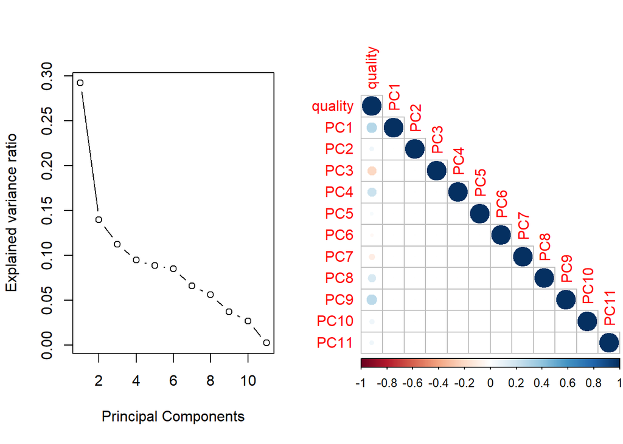

```r
par(mfrow = c(1, 2))

pca     <- prcomp(lrn[1:11], scale. = TRUE)
pca_var <- pca$sdev^2
plot(pca_var / sum(pca_var), xlab = "Principal Components",
 ylab = "Explained variance ratio",
 type = "b")

pca_data <- data.frame(quality = lrn$quality, pca$x)

corrplot(cor(pca_data), type = "lower")
```

### 3.3. Backward Elimination with PCA and ANOVA

We’ll start by building a PCA-based model and gradually eliminate components one by one — checking at each step whether the reduced model still holds up.

```r
pca_base <- add_model('pca', lm(quality ~ ., data = pca_data), TRUE)
summary(get_model(countM))
```

```
##
## Call:
## lm(formula = quality ~ ., data = pca_data)
##
## Residuals:
##     Min      1Q  Median      3Q     Max
## -3.4424 -0.4903 -0.0343  0.4565  2.4520
##
## Coefficients:
##              Estimate Std. Error t value Pr(>|t|)
## (Intercept)  5.880493   0.015041 390.967  < 2e-16 ***
## PC1          0.140118   0.008396  16.689  < 2e-16 ***
## PC2          0.043043   0.012142   3.545  0.00040 ***
## PC3         -0.163705   0.013533 -12.096  < 2e-16 ***
## PC4          0.181727   0.014750  12.320  < 2e-16 ***
## PC5          0.031171   0.015243   2.045  0.04097 *
## PC6         -0.028545   0.015576  -1.833  0.06698 .
## PC7         -0.098154   0.017661  -5.558 3.03e-08 ***
## PC8          0.184092   0.019160   9.608  < 2e-16 ***
## PC9          0.369938   0.023511  15.735  < 2e-16 ***
## PC10         0.112392   0.027739   4.052 5.24e-05 ***
## PC11         0.345491   0.093940   3.678  0.00024 ***
## ---
## Signif. codes:  0 '***' 0.001 '**' 0.01 '*' 0.05 '.' 0.1 ' ' 1
##
## Residual standard error: 0.7422 on 2423 degrees of freedom
## Multiple R-squared:  0.2916, Adjusted R-squared:  0.2884
## F-statistic: 90.68 on 11 and 2423 DF,  p-value: < 2.2e-16
```

```r
add_model('pca no pc6', lm(quality ~ . - PC6, data = pca_data), TRUE)
anova(get_model(pca_base), get_model(countM))
```

|  | Res.Df | RSS | Df | Sum of Sq | F | Pr(>F) |
| --- | --- | --- | --- | --- | --- | --- |
| 1 | 2423 | 1334.749 | NA | NA | NA | NA |
| 2 | 2424 | 1336.599 | -1 | -1.850057 | 3.35845 | 0.06698361 |

```r
summary(get_model(countM))
```

```
##
## Call:
## lm(formula = quality ~ . - PC6, data = pca_data)
##
## Residuals:
##     Min      1Q  Median      3Q     Max
## -3.4041 -0.4857 -0.0407  0.4605  2.4551
##
## Coefficients:
##             Estimate Std. Error t value Pr(>|t|)
## (Intercept)  5.88049    0.01505 390.777  < 2e-16 ***
## PC1          0.14012    0.00840  16.681  < 2e-16 ***
## PC2          0.04304    0.01215   3.543 0.000403 ***
## PC3         -0.16370    0.01354 -12.090  < 2e-16 ***
## PC4          0.18173    0.01476  12.314  < 2e-16 ***
## PC5          0.03117    0.01525   2.044 0.041065 *
## PC7         -0.09815    0.01767  -5.555 3.08e-08 ***
## PC8          0.18409    0.01917   9.603  < 2e-16 ***
## PC9          0.36994    0.02352  15.727  < 2e-16 ***
## PC10         0.11239    0.02775   4.050 5.29e-05 ***
## PC11         0.34549    0.09399   3.676 0.000242 ***
## ---
## Signif. codes:  0 '***' 0.001 '**' 0.01 '*' 0.05 '.' 0.1 ' ' 1
##
## Residual standard error: 0.7426 on 2424 degrees of freedom
## Multiple R-squared:  0.2906, Adjusted R-squared:  0.2877
## F-statistic: 99.31 on 10 and 2424 DF,  p-value: < 2.2e-16
```

After removing the component ‘PC6’, the model still performs well — in fact, we can’t reject the null hypothesis at the *α = 0.05* level, meaning the reduced model is adequate. Next, we try removing ‘PC7’ as well.

```r
add_model('pca no pc6, no pc7', lm(quality ~ . - PC6 - PC7, data = pca_data), TRUE)
anova(get_model(pca_base), get_model(countM))
```

|  | Res.Df | RSS | Df | Sum of Sq | F | Pr(>F) |
| --- | --- | --- | --- | --- | --- | --- |
| 1 | 2423 | 1334.749 | NA | NA | NA | NA |
| 2 | 2425 | 1353.614 | -2 | -18.86504 | 17.12307 | 4.126764e-08 |

```r
summary(get_model(countM))
```

```
##
## Call:
## lm(formula = quality ~ . - PC6 - PC7, data = pca_data)
##
## Residuals:
##     Min      1Q  Median      3Q     Max
## -3.5416 -0.4903 -0.0346  0.4557  2.4427
##
## Coefficients:
##              Estimate Std. Error t value Pr(>|t|)
## (Intercept)  5.880493   0.015141 388.393  < 2e-16 ***
## PC1          0.140118   0.008451  16.579  < 2e-16 ***
## PC2          0.043043   0.012223   3.521 0.000437 ***
## PC3         -0.163705   0.013623 -12.017  < 2e-16 ***
## PC4          0.181727   0.014848  12.239  < 2e-16 ***
## PC5          0.031171   0.015344   2.031 0.042314 *
## PC8          0.184092   0.019287   9.545  < 2e-16 ***
## PC9          0.369938   0.023667  15.631  < 2e-16 ***
## PC10         0.112392   0.027923   4.025 5.87e-05 ***
## PC11         0.345491   0.094563   3.654 0.000264 ***
## ---
## Signif. codes:  0 '***' 0.001 '**' 0.01 '*' 0.05 '.' 0.1 ' ' 1
##
## Residual standard error: 0.7471 on 2425 degrees of freedom
## Multiple R-squared:  0.2816, Adjusted R-squared:  0.2789
## F-statistic: 105.6 on 9 and 2425 DF,  p-value: < 2.2e-16
```

### 3.4. Model Diagnostics

Now it’s time to dive into the diagnostics for our models. We’ll look at Cook’s distance to identify and remove any outliers, then rebuild the models without those points. We’ll also calculate what percentage of our data points are considered influential and inspect residual plots for further insight.

A quick recap: *Cook’s distance* is a measure used in regression analysis to identify observations that have a large influence on the fitted model.

#### 3.4.1. Outlier Detection

We’ll create a helper function to automate the process of computing Cook’s distance and generating the necessary plots.

As a rule of thumb, any observation with a Cook’s distance greater than or equal to 1 is considered influential.

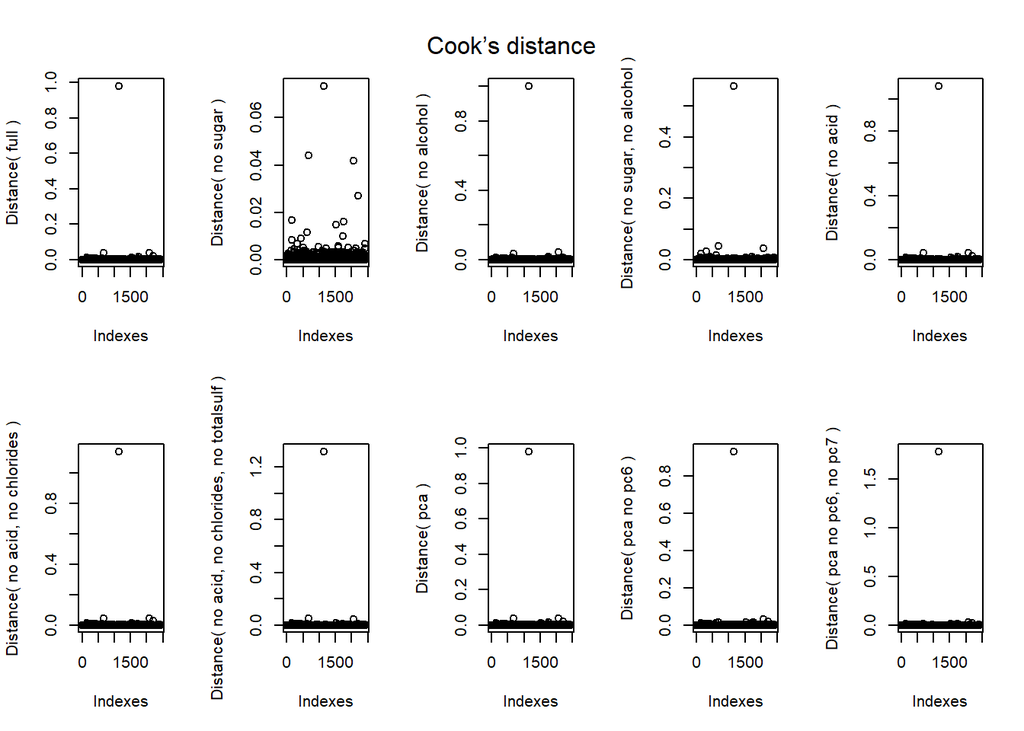

```r
cook_base = countM

cook_statistics = function(name, model, ispca){
  cook <- cooks.distance(model)
  plot(cook, xlab = "Indexes",  ylab = paste("Distance(", name, ")"))
  if(max(cook) >= 1){
    name <- paste('cook', name, sep = ' ')
    while(max(cook) >= 1){
      model <- update(model, subset = (cook < max(cook)))
      cook  <- cooks.distance(model)
    }
    add_model(name, model, ispca)
  }
}

layout(matrix(c(1,2,3,4,5,6,7,8,9,10), 2, 5, byrow = TRUE))

for(i in 1:cook_base){
  name  <- get_name(i)
  model <- get_model(i)
  cook_statistics(name, model, is_pca(i))
}

mtext("Cook’s distance", side=3, outer=TRUE, line=-3)
```

#### 3.4.2. Influential Observations

Next, we’ll focus on influential points. We’ll generate plots showing where the threshold lies for each model, to better visualize which observations cross the line.

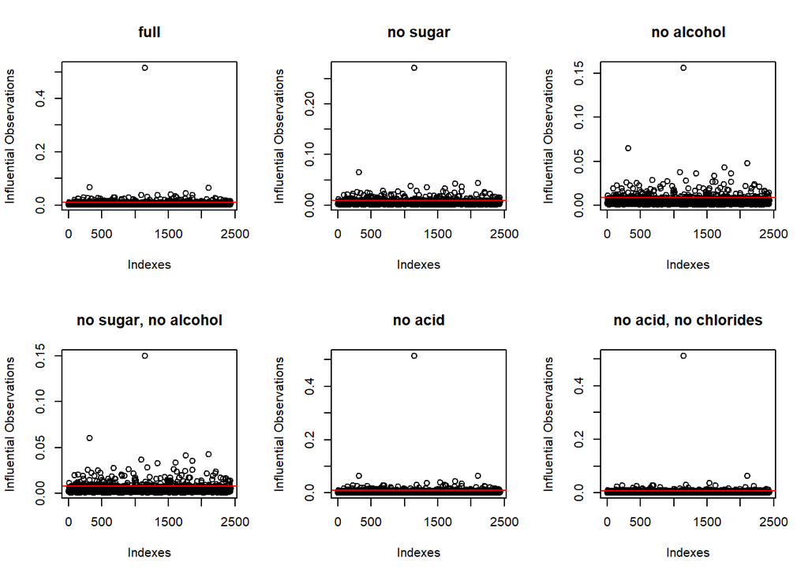

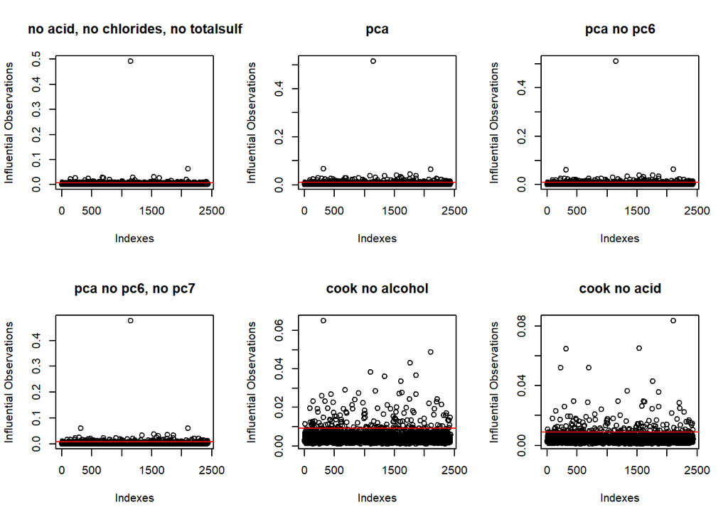

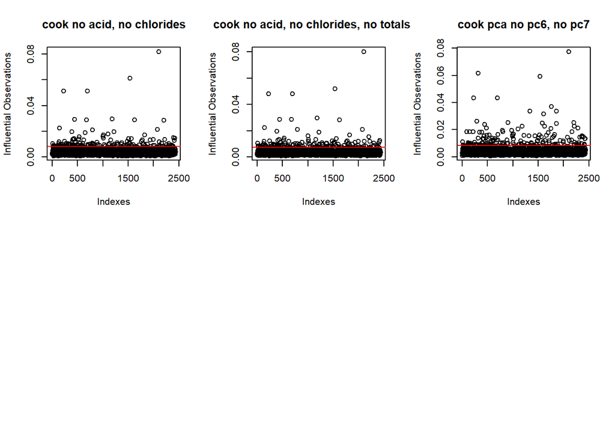

```r
par(mfrow = c(9, 3))

leverages <- mapply(function(index){
    name  <- get_name(index)
    model <- get_model(index)
    lev   <- hat(model.matrix(model))
    p <- (index - 1) %% 3
    q <- ifelse((index - 1) %% 6 >= 3, 0, 1)
    par(fig = c(1/3 * p,1/3 + 1/3 * p, 0.5 * q, 0.5 + 0.5 * q), new = (index %% 6 != 1))
    plot(lev, xlab = "Indexes", ylab = "Influential Observations", main = name)
    abline(h = 2 * sum(lev) / nrow(model$model), col = 'red')
    lev
  }, 1:countM)
```

After removing outliers, the resulting models have much cleaner plots. However, the visuals themselves aren’t particularly informative on their own — so we’ll compute the percentage of influential observations for each model and present the results in a table.

```r
data.frame(names = mapply(get_name, 1:countM),
           percentages = mapply(function(index){
                           model <- get_model(index)
                           lev   <- leverages[[index]]
                           paste(round(sum( ifelse(lev > 2 * sum(lev) / nrow(model$model), 1, 0)) / nrow(model$model) * 100, 2), '%')
                         }, 1:countM))
```

| names | percentages |
| --- | --- |
| full | 5.26 % |
| no sugar | 6.12 % |
| no alcohol | 5.91 % |
| no sugar, no alcohol | 6.41 % |
| no acid | 5.42 % |
| no acid, no chlorides | 4.64 % |
| no acid, no chlorides, no totalsulf | 4.89 % |
| pca | 5.26 % |
| pca no pc6 | 6.04 % |
| pca no pc6, no pc7 | 5.75 % |

[output cut: 5 more lines]

There’s a clear difference in how these influential observations are distributed across the various models.

#### 3.4.3. Residual Plots

Let’s also take a look at the residual plots for all models.

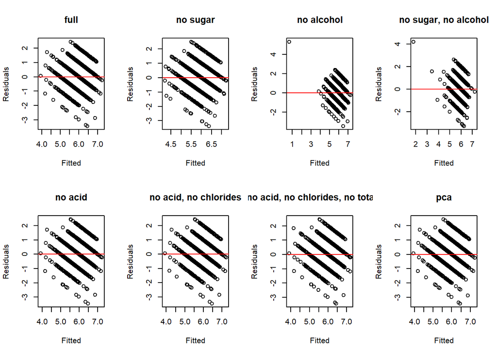

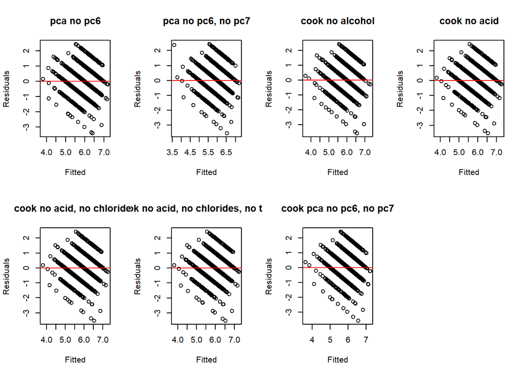

```r
par(mfrow = c(ceiling(countM / 4), 4))

for(i in 1:countM){
  model <- get_model(i)
  p <- (i - 1) %% 4
  q <- ifelse((i - 1) %% 8 >= 4, 0, 1)
  par(fig = c(1/4 * p, 1/4 + 1/4 * p, 0.5 * q, 0.5 + 0.5 * q), new = (i %% 8 != 1))
  plot(model$fit, model$res, xlab="Fitted", ylab="Residuals", main = get_name(i))
  abline(h = 0, col = 'red')}
```

In each model, we see some deviation of residuals from the fitted values. That said, the plots are fairly similar overall. Outliers identified earlier using Cook’s distance have already been removed, as shown by the differences between the original and updated models. Only the residual plots for ‘no alcohol’ and ‘no sugar, no alcohol’ stand out as looking quite different from the others.

### 3.5. Assumptions of Linear Regression

#### 3.5.1. Normality of Residuals

First, let’s inspect the residual plots.

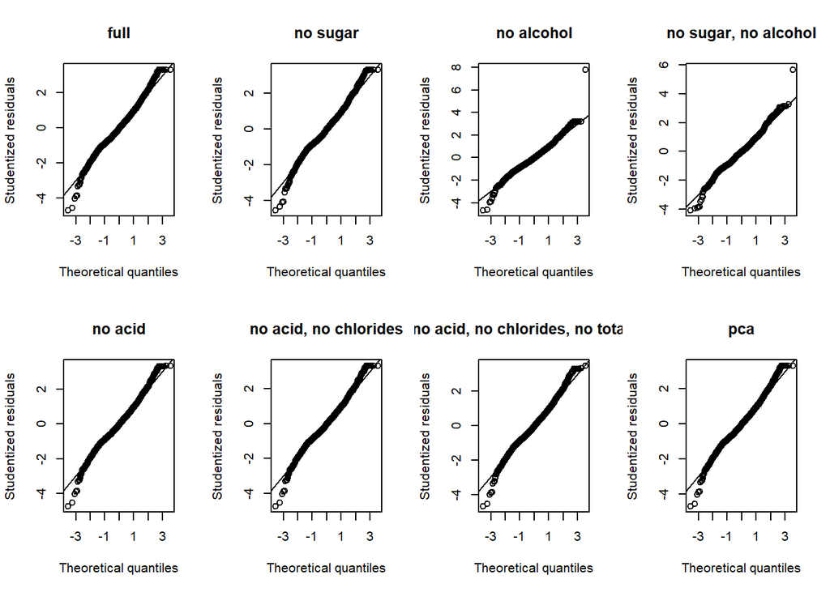

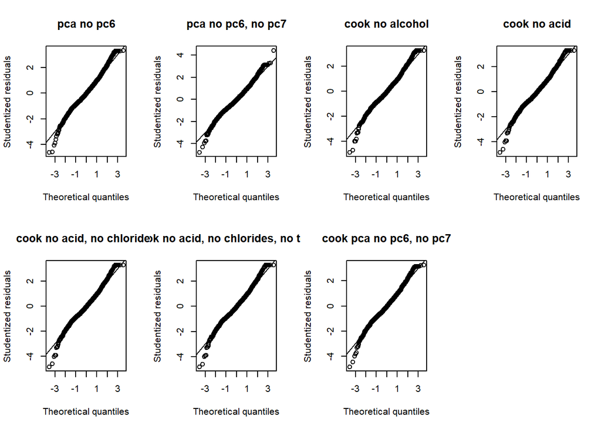

```r
par(mfrow = c(ceiling(countM / 4), 4))

for(i in 1:countM){
  model <- get_model(i)
  p <- (i - 1) %% 4
  q <- ifelse((i - 1) %% 8 >= 4, 0, 1)
  par(fig = c(1/4 * p, 1/4 + 1/4 * p, 0.5 * q, 0.5 + 0.5 * q), new = (i %% 8 != 1))
  qqnorm(rstudent(model), xlab = "Theoretical quantiles", ylab = "Studentized residuals", main = get_name(i))
  abline(0,1)
}
```

We can see that the residuals aren’t perfectly normally distributed — but the deviation is minor, and because we’re working with a large sample size, it’s not a major concern. Still, let’s formally test this using the Shapiro–Wilk test.

Here are the hypotheses:

H<sub>0</sub>: Residuals are normally distributed

H<sub>1</sub>: Residuals are not normally distributed

```r
data.frame("Model's name" = mapply(get_name, 1:countM),
           "p-value" = mapply(function(i){ shapiro.test(get_model(i)$residuals)$p.value }, 1:countM))
```

| Model.s.name | p.value |
| --- | --- |
| full | 4.545244e-12 |
| no sugar | 4.497402e-13 |
| no alcohol | 8.347294e-15 |
| no sugar, no alcohol | 5.754722e-13 |
| no acid | 7.399467e-12 |
| no acid, no chlorides | 7.659340e-12 |
| no acid, no chlorides, no totalsulf | 8.719048e-12 |
| pca | 4.545244e-12 |
| pca no pc6 | 1.544683e-11 |
| pca no pc6, no pc7 | 4.116944e-11 |

[output cut: 5 more lines]

According to the test results, we must reject H₀ — suggesting that none of the models have normally distributed residuals. This may seem contradictory to what the plots showed, but large sample sizes can make even small deviations statistically significant, which is a known limitation of such tests.

#### 3.5.2. Homoscedasticity (Constant Variance)

To test for constant variance, we’ll create residual-vs-fitted plots for each model.

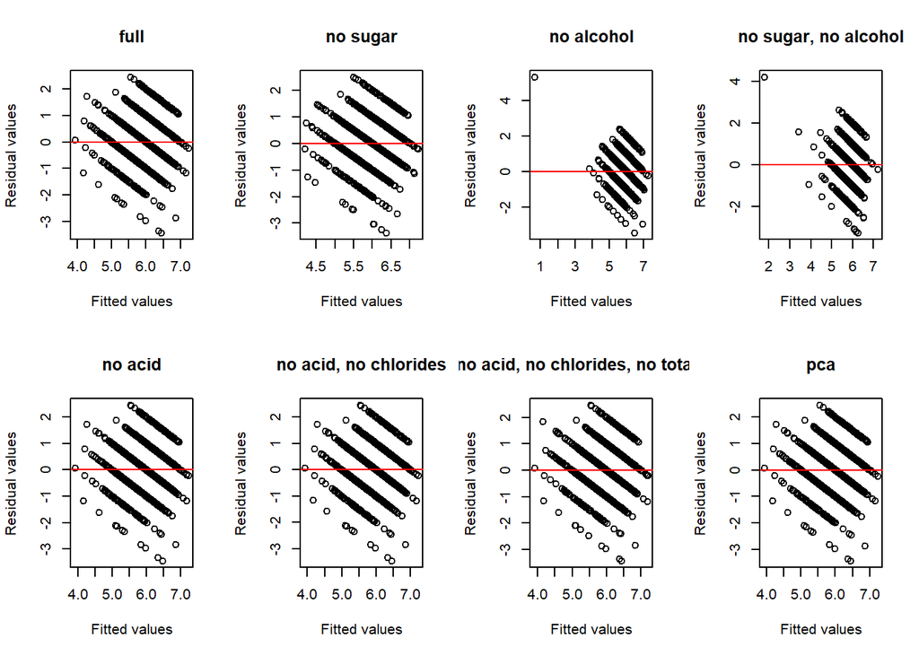

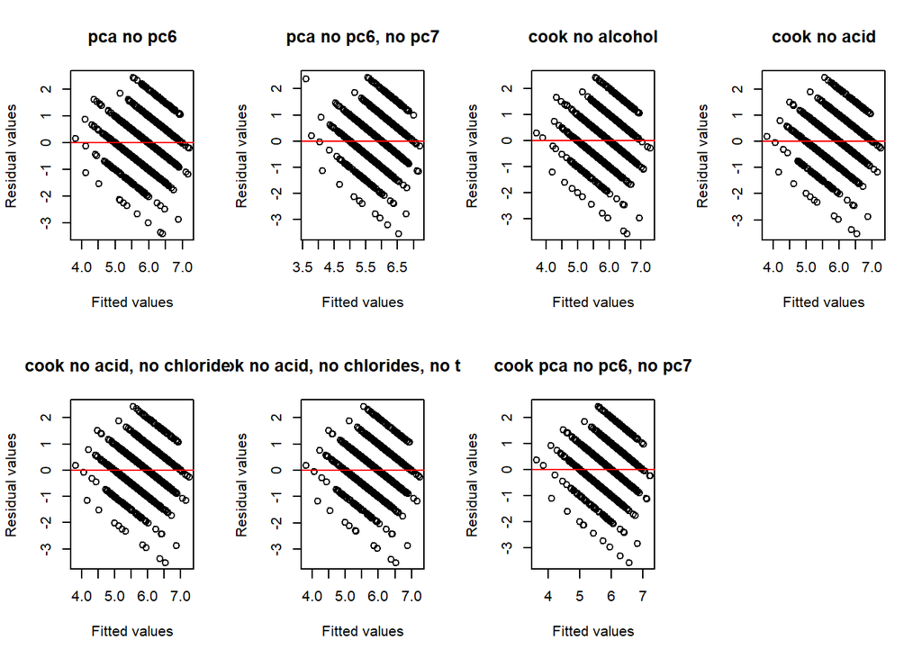

```r
par(mfrow = c(ceiling(countM / 4), 4))

for(i in 1:countM){
  model <- get_model(i)
  p <- (i - 1) %% 4
  q <- ifelse((i - 1) %% 8 >= 4, 0, 1)
  par(fig = c(1/4 * p, 1/4 + 1/4 * p, 0.5 * q, 0.5 + 0.5 * q), new = (i %% 8 != 1))
  plot(model$fit, model$res, xlab = "Fitted values", ylab = "Residual values", main = get_name(i))
  abline(h = 0, col = 'red')
}
```

We’ll also apply the Goldfeld–Quandt test, which formally checks for heteroscedasticity. Here are the hypotheses:

H<sub>0</sub>: Residuals have constant variance

H<sub>1</sub>: Residuals do not have constant variance

```r
data.frame("Models name" = mapply(get_name, 1:countM),
           "p-value" = mapply(function(i){ gqtest(get_model(i))$p.value }, 1:countM))
```

| Models.name | p.value |
| --- | --- |
| full | 0.2576003 |
| no sugar | 0.1993792 |
| no alcohol | 0.6031103 |
| no sugar, no alcohol | 0.7190410 |
| no acid | 0.2586811 |
| no acid, no chlorides | 0.2610544 |
| no acid, no chlorides, no totalsulf | 0.2707617 |
| pca | 0.2576003 |
| pca no pc6 | 0.2791648 |
| pca no pc6, no pc7 | 0.3680088 |

[output cut: 5 more lines]

Across all models, we fail to reject H₀ at the α = 0.05 level. This suggests that the assumption of constant variance holds.

#### 3.5.3. Residual Independence

To check whether residuals are correlated, we use the Durbin–Watson test. Hypotheses:

H<sub>0</sub>: Residuals are not autocorrelated

H<sub>1</sub>: Residuals are autocorrelated

```r
data.frame("Model's name" = mapply(get_name, 1:countM),
           "p-value" = mapply(function(i){ durbinWatsonTest(get_model(i))$p }, 1:countM))
```

| Model.s.name | p.value |
| --- | --- |
| full | 0.196 |
| no sugar | 0.072 |
| no alcohol | 0.394 |
| no sugar, no alcohol | 0.096 |
| no acid | 0.186 |
| no acid, no chlorides | 0.198 |
| no acid, no chlorides, no totalsulf | 0.174 |
| pca | 0.220 |
| pca no pc6 | 0.220 |
| pca no pc6, no pc7 | 0.094 |

[output cut: 5 more lines]

Test results show no reason to reject H<sub>0</sub> — in other words, residuals appear to be uncorrelated in all our models.

### 3.6. Multicollinearity of Predictors

```r
VIF = function(i){
  data.frame("Name" = get_name(i), t(vif(get_model(i))))
}
```

This simple test, based on R² values, tells us how much a variable’s variance is inflated due to correlations with other predictors.

### 3.7. Goodness-of-Fit Measures

Before selecting the best model, let’s examine how well each model fits the data using standard fit metrics.

```r
data.frame("Model's name" = mapply(get_name, 1:countM),
           "Adjusted R-squared"  = mapply(function(index){summary(get_model(index))$adj.r.squared}, 1:countM),
           "Estimator of error variance" = mapply(function(index){summary(get_model(index))$sigma}, 1:countM),
           check.names = FALSE)
```

| Model's name | Adjusted R-squared | Estimator of error variance |
| --- | --- | --- |
| full | 0.2884027 | 0.7422036 |
| no sugar | 0.2732637 | 0.7500571 |
| no alcohol | 0.2693532 | 0.7520724 |
| no sugar, no alcohol | 0.1570651 | 0.8077983 |
| no acid | 0.2883562 | 0.7422278 |
| no acid, no chlorides | 0.2886047 | 0.7420983 |
| no acid, no chlorides, no totalsulf | 0.2883723 | 0.7422195 |
| pca | 0.2884027 | 0.7422036 |
| pca no pc6 | 0.2877103 | 0.7425646 |
| pca no pc6, no pc7 | 0.2789403 | 0.7471220 |

[output cut: 5 more lines]

Looking at the results, if we were to base our choice solely on the adjusted R-squared, the best model would be ‘cook no acid, no chlorides, no totalsulf’. However, our selection will be based on the Residual Sum of Squares (RSS) instead.

### 3.8. Best Model Selection Based on RSS and Model Evaluation

We’ll create a function that returns the following for each model: the model name, the residual sum of squares between the validation sample and predicted values, the percentage of correct classifications, and the percentage of classifications within ±1 of the true value.

```r
pca_val <- as.data.frame(predict(pca, newdata = val[1:11]))
pca_tst <- as.data.frame(predict(pca, newdata = tst[1:11]))
```

```r
prediction_summary <- data.frame(matrix(ncol = 4, nrow = 0, dimnames = list(NULL, c("Name", "RSS", "Percentage of correct predictions","Percentage of differences"))))
```

```r
make_prediction = function(index, non_pca, iff_pca){
  name  <- get_name(index)
  model <- get_model(index)
  if(is_pca(index)){
    prediction <- round(predict(model, iff_pca))
  }else{
    prediction <- round(predict(model, non_pca[1:11]))
  }
  prediction_summary[nrow(prediction_summary) + 1,] <<- c(name,
    sum((prediction - non_pca[12])^2),
    sum(non_pca[12] == prediction, na.rm = TRUE) / nrow(non_pca[12]) * 100,
    sum(abs(non_pca[12] - prediction) <= 1)/ nrow(non_pca[12]) * 100)
}
```

```r
for(i in 1:countM){ make_prediction(i, val, pca_val) }
```

```r
prediction_summary
```

|  | Name | RSS | Percentage.of.correct.predictions | Percentage.of.differences |
| --- | --- | --- | --- | --- |
| 1 | full | 809 | 50.9031198686371 | 94.4991789819376 |
| 2 | no sugar | 806 | 51.3957307060755 | 94.4170771756979 |
| 3 | no alcohol | 794 | 51.3957307060755 | 94.7454844006568 |
| 4 | no sugar, no alcohol | 927 | 47.6190476190476 | 92.7750410509031 |
| 5 | no acid | 797 | 51.1494252873563 | 94.7454844006568 |
| 6 | no acid, no chlorides | 798 | 51.3136288998358 | 94.6633825944171 |
| 7 | no acid, no chlorides, no totalsulf | 788 | 51.6420361247947 | 94.8275862068966 |
| 8 | pca | 809 | 50.9031198686371 | 94.4991789819376 |
| 9 | pca no pc6 | 790 | 51.4778325123153 | 94.8275862068966 |
| 10 | pca no pc6, no pc7 | 772 | 51.6420361247947 | 95.4022988505747 |

[output cut: 5 more lines]

```r
prediction_summary <- data.frame(matrix(ncol = 4, nrow = 0, dimnames = list(NULL, c("Name", "RSS", "Percentage of correct predictions","Percentage of differences"))))

make_prediction(9, tst, pca_tst)

prediction_summary
```

|  | Name | RSS | Percentage.of.correct.predictions | Percentage.of.differences |
| --- | --- | --- | --- | --- |
| 1 | pca no pc6 | 827 | 51.1092851273624 | 95.0698438783895 |

## 4. Proportional Odds Model

To adapt the quality variable into a categorical format, we’ll build a proportional odds (ordinal logistic regression) model.

```r
wine1 <- white_numeric
wine1$quality <- factor(wine1$quality)
```

We’ll again split the data into the same three subsets as before.

```r
lrn2 <- wine1[I_l,]
val2 <- wine1[I_v,]
tst2 <- wine1[I_t,]
```

The initial model is constructed as follows:

```r
g.plr <- polr(quality ~ ., data = lrn2)
g.plr
```

```
## Call:
## polr(formula = quality ~ ., data = lrn2)
##
## Coefficients:
##        fixed.acidity     volatile.acidity          citric.acid
##         1.171114e-01        -5.037121e+00         5.143532e-01
##       residual.sugar            chlorides  free.sulfur.dioxide
##         1.874274e-01         3.926045e-01         1.429007e-02
## total.sulfur.dioxide              density                   pH
##        -2.226968e-03        -3.128114e+02         1.866293e+00
##            sulphates              alcohol
##         1.555264e+00         6.349557e-01
##
## Intercepts:
##       3|4       4|5       5|6       6|7       7|8       8|9
## -302.8883 -300.5129 -297.5061 -294.8270 -292.6198 1869.6047
##
## Residual Deviance: 5350.84
## AIC: 5384.84
```

Now, let’s look at the model summary.

```r
summary(g.plr)
```

```
##
## Ponowne dopasowywanie aby uzyskać hesjan
```

```
## Call:
## polr(formula = quality ~ ., data = lrn2)
##
## Coefficients:
##                           Value Std. Error   t value
## fixed.acidity         1.171e-01   0.053719    2.1801
## volatile.acidity     -5.037e+00   0.435293  -11.5718
## citric.acid           5.144e-01   0.334881    1.5359
## residual.sugar        1.874e-01   0.009756   19.2125
## chlorides             3.926e-01   1.933109    0.2031
## free.sulfur.dioxide   1.429e-02   0.003169    4.5100
## total.sulfur.dioxide -2.227e-03   0.001344   -1.6567
## density              -3.128e+02   0.658271 -475.2012
## pH                    1.866e+00   0.299841    6.2243
## sulphates             1.555e+00   0.348255    4.4659
## alcohol               6.350e-01   0.044907   14.1393
##
## Intercepts:
##     Value     Std. Error t value
## 3|4 -302.8883    0.6702  -451.9593
## 4|5 -300.5129    0.6671  -450.4928
## 5|6 -297.5061    0.6739  -441.4666
## 6|7 -294.8270    0.6889  -427.9466
## 7|8 -292.6198    0.7016  -417.0619
## 8|9 1869.6047    0.7016  2664.6892
##
## Residual Deviance: 5350.84
## AIC: 5384.84
```

We use the predict() function to make predictions with this model.

```r
pr_log1 <- predict(g.plr, val2[,1:11], type="class")

val21 <- as.numeric(val2$quality)
pr_log11 <- as.numeric(pr_log1)
```

Then we compute the residual sum of squares.

```r
sum((pr_log11-val21)^2)
```

```
## [1] 805
```

We can see that the model is average, so we’ll try to improve it. We’ll simplify the model using the step function.

```r
o_lr = step(g.plr)
```

```
## Start:  AIC=5384.84
## quality ~ fixed.acidity + volatile.acidity + citric.acid + residual.sugar +
##     chlorides + free.sulfur.dioxide + total.sulfur.dioxide +
##     density + pH + sulphates + alcohol
##
##                        Df    AIC
## - chlorides             1 5382.9
## <none>                    5384.8
## - fixed.acidity         1 5384.9
## - citric.acid           1 5385.2
## - total.sulfur.dioxide  1 5385.4
## - sulphates             1 5401.0
## - free.sulfur.dioxide   1 5402.8
## - density               1 5403.2
## - pH                    1 5405.8
## - alcohol               1 5418.9
## - residual.sugar        1 5429.9
## - volatile.acidity      1 5518.5
##
## Step:  AIC=5382.88
## quality ~ fixed.acidity + volatile.acidity + citric.acid + residual.sugar +
##     free.sulfur.dioxide + total.sulfur.dioxide + density + pH +
##     sulphates + alcohol
##
##                        Df    AIC
## <none>                    5382.9
## - citric.acid           1 5383.4
## - total.sulfur.dioxide  1 5383.5
## - fixed.acidity         1 5386.3
## - sulphates             1 5399.1
## - free.sulfur.dioxide   1 5401.0
## - density               1 5401.7
## - pH                    1 5407.8
## - alcohol               1 5417.5
## - residual.sugar        1 5430.1
## - volatile.acidity      1 5521.4
```

The model turns out to be mediocre, so we attempt to improve it. We simplify the model using the step() function to minimize the AIC — a criterion that estimates the information lost by a model. The smaller the AIC, the better the model in terms of avoiding overfitting or underfitting.

Let’s look at the summary of the reduced model.

```r
summary(o_lr)
```

```
##
## Ponowne dopasowywanie aby uzyskać hesjan
```

```
## Call:
## polr(formula = quality ~ fixed.acidity + volatile.acidity + citric.acid +
##     residual.sugar + free.sulfur.dioxide + total.sulfur.dioxide +
##     density + pH + sulphates + alcohol, data = lrn2)
##
## Coefficients:
##                           Value Std. Error  t value
## fixed.acidity         1.137e-01   0.053480    2.126
## volatile.acidity     -5.028e+00   0.432303  -11.631
## citric.acid           5.254e-01   0.329697    1.594
## residual.sugar        1.859e-01   0.009624   19.321
## free.sulfur.dioxide   1.432e-02   0.003168    4.520
## total.sulfur.dioxide -2.232e-03   0.001344   -1.661
## density              -3.095e+02   0.639628 -483.932
## pH                    1.851e+00   0.298762    6.194
## sulphates             1.550e+00   0.348192    4.451
## alcohol               6.359e-01   0.042742   14.878
##
## Intercepts:
##     Value     Std. Error t value
## 3|4 -299.7198    0.6485  -462.1784
## 4|5 -297.3445    0.6455  -460.6453
## 5|6 -294.3376    0.6528  -450.8736
## 6|7 -291.6586    0.6685  -436.2950
## 7|8 -289.4515    0.6816  -424.6866
## 8|9 1800.4887    0.6816  2641.6981
##
## Residual Deviance: 5350.88
## AIC: 5382.88
```

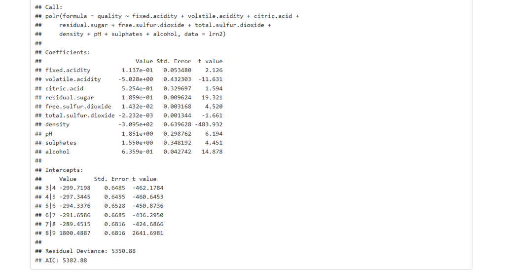

```r
anova(g.plr,o_lr)
```

| Model | Resid. df | Resid. Dev | Test | Df | LR stat. | Pr(Chi) |
| --- | --- | --- | --- | --- | --- | --- |
| fixed.acidity + volatile.acidity + citric.acid + residual.sugar + free.sulfur.dioxide + total.sulfur.dioxide + density + pH + sulphates + alcohol | 2419 | 5350.88 |  | NA | NA | NA |
| fixed.acidity + volatile.acidity + citric.acid + residual.sugar + chlorides + free.sulfur.dioxide + total.sulfur.dioxide + density + pH + sulphates + alcohol | 2418 | 5350.84 | 1 vs 2 | 1 | 0.03975412 | 0.8419621 |

[figure not shown]

We see that this smaller model is statistically justified. However, when we recalculate the residual sum of squares…

```r
pr_log2<-predict(o_lr, val2[,1:11],type="class")

val21<- as.numeric(val2$quality)
pr_log12 <- as.numeric(pr_log2)
sum((pr_log12-val21)^2)
```

```
## [1] 807
```

…it turns out to be larger than for the full model. So, based on this criterion, the simplified model is not better. In fact, neither of the proportional odds models outperform the best linear regression model we selected earlier.

## 5. Summary

Of course, additional models could be developed by excluding further outliers or refining feature selection. However, we chose to focus only on a limited number of models. Still, our findings suggest that linear regression is not an ideal modeling technique for this dataset, as it exhibits significant limitations in predictive accuracy.